# 16S_Lesson

Donny Hoang

3/25/2020

## Goal: Familiarize yourself with 16S Amplicon sequence analysis.

We will achieve this goal by following along the [dada2 pipeline.](https://benjjneb.github.io/dada2/tutorial.html) I have copied it here, but with our own data, so following along should be easier. Tbh, a lot of the nitty-gritty is over my head, but I’ll try my best to answer your questions as you go through this. If you are curious, I recommend checking [their paper.](https://www.nature.com/articles/nmeth.3869#methods)

We are working with raw sequences. Broadly, we want to trim+filter poor quality reads, denoise our F and R reads, merge our F and R reads, remove chimeras, and then assign taxonomy to the sequences.

## Dataset

We are working with a 16S rRNA sequencing dataset. This technique is based on the amplification of hypervariable regions with the 16S rRNA gene, and these sequences can be compared to databases for taxonomic identification. 16S amplicon sequencing is typically used to survey the bacterial and/or archael composition of a sample.

A former Currie Lab graduate student, Dr. Gina Lewin, experimentally evolved a bacterial community to degrade cellulose more quickly. These communities were transferred approxiamtely every 3-4 days for the first 73 transfers, then every 7 days following that. We wanted to know if these communities followed different successional patterns throughout the course of their maintenance. Lindsay and I regrew this community from freeezer stocks at transfer 56 (before the change), 73 (at the change), 94 (after the change), and 110 (way after the change). Then, we destructively sampled over the course of one week starting on Day 2. These samples were sent out for 16S amplicon sequencing using Illumina MiSeq 2x300 bp. You will analyze one set of samples (to save space on your computer) and we will compare our results to each other at the end of this lesson.

Broadly, we want to trim+filter poor quality reads, denoise our F and R reads, merge our F and R reads, remove chimeras, and then assign taxonomy to the sequences.

## Excercise

### Load dada2 and your data

Your output may look different than what is presented here, because you will be working with different sets of data.

We have a lot more data than we did the previous lessons. My data is stored in a folder called “110_16S”. I recommend storing your data in it’s own folder accessible from your working directory.

```r
library(dada2) #load dada2 package
path <-"110_16S/" #set path to folder containing data files
list.files(path) #view files
```

```
##  [1] "110-2A_S126_L001_R1_001.fastq.gz" "110-2A_S126_L001_R2_001.fastq.gz"
##  [3] "110-2B_S127_L001_R1_001.fastq.gz" "110-2B_S127_L001_R2_001.fastq.gz"
##  [5] "110-2C_S128_L001_R1_001.fastq.gz" "110-2C_S128_L001_R2_001.fastq.gz"
##  [7] "110-3A_S129_L001_R1_001.fastq.gz" "110-3A_S129_L001_R2_001.fastq.gz"
##  [9] "110-3B_S130_L001_R1_001.fastq.gz" "110-3B_S130_L001_R2_001.fastq.gz"
## [11] "110-3C_S131_L001_R1_001.fastq.gz" "110-3C_S131_L001_R2_001.fastq.gz"
## [13] "110-4A_S132_L001_R1_001.fastq.gz" "110-4A_S132_L001_R2_001.fastq.gz"
## [15] "110-4B_S133_L001_R1_001.fastq.gz" "110-4B_S133_L001_R2_001.fastq.gz"
## [17] "110-4C_S134_L001_R1_001.fastq.gz" "110-4C_S134_L001_R2_001.fastq.gz"
## [19] "110-5A_S135_L001_R1_001.fastq.gz" "110-5A_S135_L001_R2_001.fastq.gz"
## [21] "110-5B_S136_L001_R1_001.fastq.gz" "110-5B_S136_L001_R2_001.fastq.gz"
## [23] "110-5C_S137_L001_R1_001.fastq.gz" "110-5C_S137_L001_R2_001.fastq.gz"
## [25] "110-6A_S138_L001_R1_001.fastq.gz" "110-6A_S138_L001_R2_001.fastq.gz"
## [27] "110-6B_S139_L001_R1_001.fastq.gz" "110-6B_S139_L001_R2_001.fastq.gz"
## [29] "110-6C_S140_L001_R1_001.fastq.gz" "110-6C_S140_L001_R2_001.fastq.gz"
## [31] "110-7A_S141_L001_R1_001.fastq.gz" "110-7A_S141_L001_R2_001.fastq.gz"
## [33] "110-7B_S142_L001_R1_001.fastq.gz" "110-7B_S142_L001_R2_001.fastq.gz"
## [35] "110-7C_S143_L001_R1_001.fastq.gz" "110-7C_S143_L001_R2_001.fastq.gz"
## [37] "filtered"
```

What I hope you notice is that every sample has two files: a forward read, and a reverse read. This is denoted by "_R1_001.fastq.gz" and "_R2_001.fastq.gz" respectively.

Next, let’s import the files.

```r
fnFs <- sort(list.files(path, pattern="_R1_001.fastq.gz", full.names = TRUE)) #import forward reads
fnRs <- sort(list.files(path, pattern="_R2_001.fastq.gz", full.names = TRUE)) #import reverse reads
sample.names <- sapply(strsplit(basename(fnFs), "_"), `[`, 1) #extract sample names
```

Here, we are storing our F and R reads into their own object, and storing sample names. Can you figure out what the sapply() function is doing? We are extracting sample names only from the fnFs object because the fnRs object woul have the same name.

### Quality check our reads

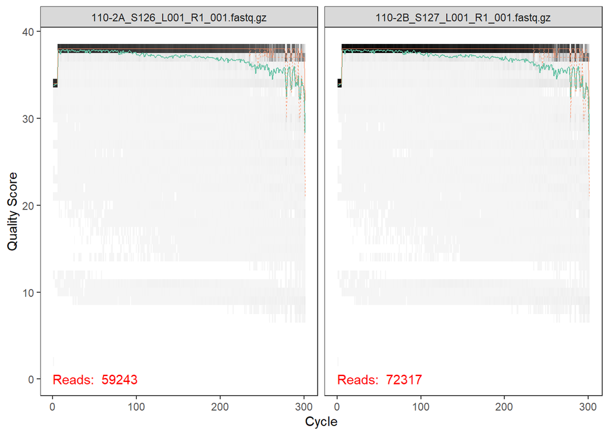

```r
plotQualityProfile(fnFs[1:2]) #plot quality score of forward reads
```

Let’s look at the reverse reads.

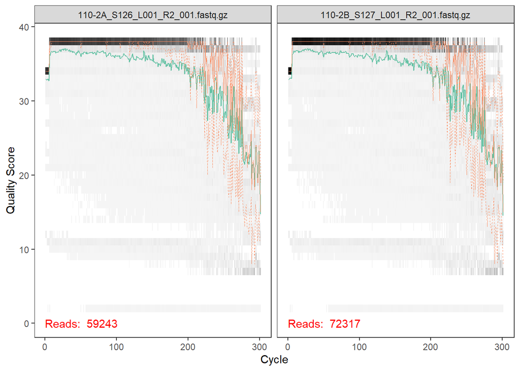

```r
plotQualityProfile(fnRs[1:2]) #plot quality score of reverse reads
```

lol these are so much worse. I’m gonna chop it off at the 225 position. Your data will have the same cutoffs as they were done on the same sequencing run.

### Trim and merge our reads

```r
filtFs <- file.path(path, "filtered", paste0(sample.names, "_F_filt.fastq.gz")) #create object holding filtered F reads.
filtRs <- file.path(path, "filtered", paste0(sample.names, "_R_filt.fastq.gz")) #create object holding filtered R reads
names(filtFs) <- sample.names #name
names(filtRs) <- sample.names #name


#This following step will take a few minutes. Get a drink or take a small break!
out <- filterAndTrim(fnFs, filtFs, fnRs, filtRs, #specify input+output
                     truncLen=c(280,225), #where we are cutting off our sequences
                     trimLeft = c(17,21), #explanation below
                     maxN=0, maxEE=c(2,2), truncQ=2, rm.phix=TRUE, #default parameters
                     compress=TRUE, multithread=FALSE) #my multitread is set to FALSE bc I run on Windows. Set yours to TRUE if you're on a MAC

head(out)
```

```
##                                  reads.in reads.out
## 110-2A_S126_L001_R1_001.fastq.gz    59243     51665
## 110-2B_S127_L001_R1_001.fastq.gz    72317     63230
## 110-2C_S128_L001_R1_001.fastq.gz    66174     58107
## 110-3A_S129_L001_R1_001.fastq.gz    65095     56647
## 110-3B_S130_L001_R1_001.fastq.gz    64767     56062
## 110-3C_S131_L001_R1_001.fastq.gz    74984     65443
```

trimLeft() will trim off any primer sequences from our amplicon, because primers can disrupt downstream processing. I ran through this pipeline a couple times with different numbers, and (17,21) seems to work best for this particular dataset. Some datasets may not require any trimming, and others many require more or less trimming.

Looks like I’ve kept most of my reads. Great! Let’s move on to learning error rates.

### Learn error rates

```r
#The following steps will take a few minutes. Relax and enjoy the downtime!

errF <- learnErrors(filtFs, multithread=FALSE) #my multitread is set to FALSE bc I run on Windows. Set yours to TRUE if you're on a MAC
```

```
## 109792506 total bases in 417462 reads from 7 samples will be used for learning the error rates.
```

```r
errR <- learnErrors(filtRs, multithread=FALSE) #my multitread is set to FALSE bc I run on Windows. Set yours to TRUE if you're on a MAC
```

```
## 105453924 total bases in 516931 reads from 9 samples will be used for learning the error rates.
```

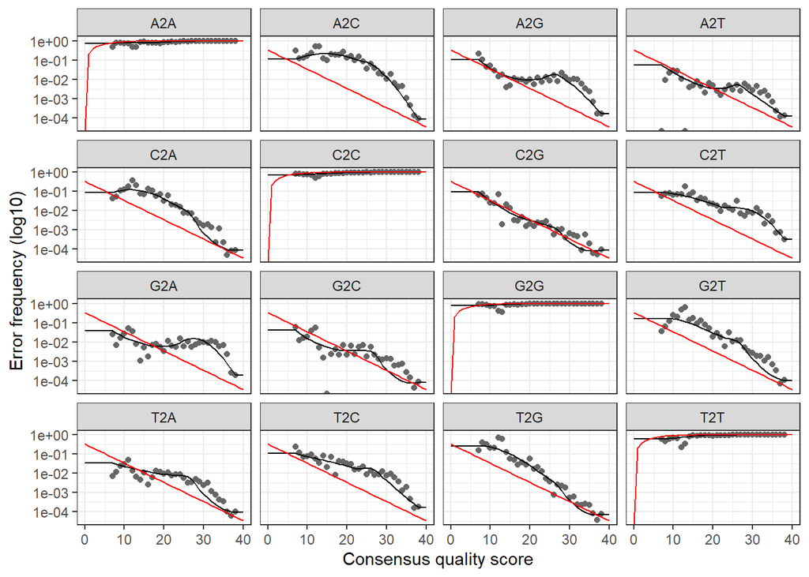

```r
plotErrors(errF, nominalQ=TRUE)
```

Here, we estimated error rates. The y-axis is error rate frequency, and the x-axis represents the consensus quality score. The black line is our estimated error rate, and the dots are the observed error rate. Importantly, the estimated error rate seems like a good fit for our observed error rates. Let’s move forward.

### Sample inference

```r
#This step also takes a couple minutes. Hope you're comfortable!

dadaFs <- dada(filtFs, err=errF, multithread=FALSE) #my multitread is set to FALSE bc I run on Windows. Set yours to TRUE if you're on a MAC
```

```
## Sample 1 - 51665 reads in 4041 unique sequences.
## Sample 2 - 63230 reads in 4704 unique sequences.
## Sample 3 - 58107 reads in 4371 unique sequences.
## Sample 4 - 56647 reads in 4861 unique sequences.
## Sample 5 - 56062 reads in 4250 unique sequences.
## Sample 6 - 65443 reads in 5110 unique sequences.
## Sample 7 - 66308 reads in 5355 unique sequences.
## Sample 8 - 49852 reads in 4656 unique sequences.
## Sample 9 - 49617 reads in 4756 unique sequences.
## Sample 10 - 53387 reads in 5308 unique sequences.
## Sample 11 - 66726 reads in 5407 unique sequences.
## Sample 12 - 62860 reads in 5793 unique sequences.
## Sample 13 - 69778 reads in 6120 unique sequences.
## Sample 14 - 30973 reads in 3837 unique sequences.
## Sample 15 - 75331 reads in 6910 unique sequences.
## Sample 16 - 58942 reads in 8065 unique sequences.
## Sample 17 - 56204 reads in 7731 unique sequences.
## Sample 18 - 56812 reads in 6886 unique sequences.
```

```r
dadaRs <- dada(filtRs, err=errR, multithread=FALSE) #my multitread is set to FALSE bc I run on Windows. Set yours to TRUE if you're on a MAC
```

```
## Sample 1 - 51665 reads in 5217 unique sequences.
## Sample 2 - 63230 reads in 5886 unique sequences.
## Sample 3 - 58107 reads in 5395 unique sequences.
## Sample 4 - 56647 reads in 5853 unique sequences.
## Sample 5 - 56062 reads in 5845 unique sequences.
## Sample 6 - 65443 reads in 6673 unique sequences.
## Sample 7 - 66308 reads in 6940 unique sequences.
## Sample 8 - 49852 reads in 5941 unique sequences.
## Sample 9 - 49617 reads in 6523 unique sequences.
## Sample 10 - 53387 reads in 6616 unique sequences.
## Sample 11 - 66726 reads in 6874 unique sequences.
## Sample 12 - 62860 reads in 7312 unique sequences.
## Sample 13 - 69778 reads in 8153 unique sequences.
## Sample 14 - 30973 reads in 4406 unique sequences.
## Sample 15 - 75331 reads in 8213 unique sequences.
## Sample 16 - 58942 reads in 8631 unique sequences.
## Sample 17 - 56204 reads in 8280 unique sequences.
## Sample 18 - 56812 reads in 7609 unique sequences.
```

```r
dadaFs[[1]]
```

```
## dada-class: object describing DADA2 denoising results
## 45 sequence variants were inferred from 4041 input unique sequences.
## Key parameters: OMEGA_A = 1e-40, OMEGA_C = 1e-40, BAND_SIZE = 16
```

The dada2 algorithm has inferred that I have 45 “true sequence variants”, which are inferred from the 4041 sequences in inputted. What does your output say?

### Merge paired reads.

```r
mergers <- mergePairs(dadaFs, filtFs, dadaRs, filtRs, verbose=FALSE) #merge paired reads
head(mergers[[1]]) # inspect the merger data.frame from the first sample
```

```
##                                                                                                                                                                                                                                                                                                          …
## 1 TGGGGAATATTGGACAATGGGGGCAACCCTGATCCAGCCATGCCGCGTGTGTGAAGAAGG…
## 2                          TGGGGAATCTTGCGCAATGGGCGAAAGCCTGACGCAGCCATGCCGCGTGAATGATGAAGG…
## 3      TGAGGAATATTGGTCAATGGACGGAAGTCTGAACCAGCCATGCCGCGTGAAGGATGAAGG…
## 4 TGGGGAATATTGGACAATGGGCGAAAGCCTGATCCAGCCATGCCGCGTGTGTGAAGAAGG…
## 5      TAGGGAATATTGGGCAATGGAGGCAACTCTGACCCAGCCATGCCGCGTGCAGGAAGACGG…
## 6      TAAGGAATATTGGTCAATGGACGAAAGTCTGAACCAGCTATGCCGCGTGGAGGATGAAGG…
##   abundance forward reverse nmatch nmismatch nindel prefer accept
## 1     46035       1       1     41         0      0      1   TRUE
## 2      1476       2       2     66         0      0      2   TRUE
## 3      1216       3       3     46         0      0      1   TRUE
## 4       806       4       4     41         0      0      1   TRUE
## 5       441       5       5     46         0      0      1   TRUE
## 6       244       6       7     46         0      0      1   TRUE
```

The mergers object we created contains a list of data.frames. Each data.frame contains a column for the merged sequence, its abundance, and the indices of the F and R sequence varients that got merged.

### Construct sequence table and remove chimeras

```r
seqtab <- makeSequenceTable(mergers) #create sequence table that is imput for chimera removing function
dim(seqtab) #Check number of ASV's before chimera removal
```

```
## [1]  18 375
```

```r
seqtab.nochim <- removeBimeraDenovo(seqtab, method="consensus", multithread=FALSE, verbose=FALSE) #my multitread is set to FALSE bc I run on Windows. Set yours to TRUE if you're on a MAC

dim(seqtab.nochim)#check number of ASV's after chimera removal
```

```
## [1]  18 107
```

```r
sum(seqtab.nochim)/sum(seqtab) #check abundance of chimeras
```

```
## [1] 0.9899817
```

How do your numbers compare? How many of your ASVs were chimeras? What was their abundance?

### Track reads through the pipeline

For progress’ sake, let’s check how many reads we’ve lost throughout this process.

```r
getN <- function(x) sum(getUniques(x))
track <- cbind(out, sapply(dadaFs, getN), sapply(dadaRs, getN), sapply(mergers, getN), rowSums(seqtab.nochim))

colnames(track) <- c("input", "filtered", "denoisedF", "denoisedR", "merged", "nonchim")
rownames(track) <- sample.names
head(track)
```

```
##        input filtered denoisedF denoisedR merged nonchim
## 110-2A 59243    51665     51603     51599  51368   51298
## 110-2B 72317    63230     63130     63169  62838   62772
## 110-2C 66174    58107     58041     58055  57798   57723
## 110-3A 65095    56647     56559     56567  56274   55648
## 110-3B 64767    56062     56007     55979  55697   55609
## 110-3C 74984    65443     65359     65364  64994   64782
```

Looks like we’ve kept most of our reads throughout this process. I don’t see a step where we ended up losing a majority of our reads.

How do your numbers compare? Are they similar? Do you see any points along the pipeline where you lost a bunch of reads?

### Assign taxonomy

We have identied all our unqiue ASVs and their abundance. Now it’s time to assign taxonomy to their sequences, and see what microbes they came from.

```r
#This step takes a few minutes.

taxa <- assignTaxonomy(seqtab.nochim, "tax/silva_nr_v132_train_set.fa.gz", multithread=FALSE) #my multitread is set to FALSE bc I run on Windows. Set yours to TRUE if you're on a MAC
taxa.print <- taxa # Removing sequence rownames for display only
rownames(taxa.print) <- NULL
head(taxa.print)
```

```
##      Kingdom    Phylum           Class                 Order
## [1,] "Bacteria" "Proteobacteria" "Gammaproteobacteria" "Cellvibrionales"
## [2,] "Bacteria" "Bacteroidetes"  "Bacteroidia"         "Chitinophagales"
## [3,] "Bacteria" "Proteobacteria" "Gammaproteobacteria" "Betaproteobacteriales"
## [4,] "Bacteria" "Bacteroidetes"  "Bacteroidia"         "Chitinophagales"
## [5,] "Bacteria" "Proteobacteria" "Gammaproteobacteria" "Pseudomonadales"
## [6,] "Bacteria" "Proteobacteria" "Alphaproteobacteria" "Caulobacterales"
##      Family             Genus
## [1,] "Cellvibrionaceae" "Cellvibrio"
## [2,] "Chitinophagaceae" "Taibaiella"
## [3,] "Rhodocyclaceae"   "Azonexus"
## [4,] "Chitinophagaceae" "Terrimonas"
## [5,] "Pseudomonadaceae" "Pseudomonas"
## [6,] "Caulobacteraceae" "Asticcacaulis"
```

The majority of my reads are from *Cellvibrio*, a known cellulose degrader. I think this finding makes sense, since we sequenced a cellulose degrading community.

One last thing before we finish for today. Let’s save our outputs so we can use them for the next lesson. We want:

1. The fasta file has each of our ASVs, and their corresponding sequence.
2. The count table tells us how many of each sequence we have in each sample.
3. The taxonomy table tells us the taxonomic assignment of each ASV.

```r
#give seq headers more manageable names (ASV_1, ASV_2...)
seqs <- colnames(seqtab.nochim)
headers <- vector(dim(seqtab.nochim)[2], mode="character")

for (i in 1:dim(seqtab.nochim)[2]) {
  headers[i] <- paste(">ASV", i, sep="_")
}

#fasta file
fasta <- c(rbind(headers, seqs)) #make fasta file
write(fasta, "110_seqs.fa") #write out as .fasta file

#count table
count_tab <- t(seqtab.nochim) #make count table
row.names(count_tab) <- sub(">", "", headers) #replace rownames with something that is easy to follow
write.csv(count_tab, "110_counts.csv", row.names=TRUE) #write out as .csv file


# tax table:
tax <- taxa #make taxonomy table
row.names(tax) <- sub(">", "", headers) #replace rownames with something that is easy to follow
write.csv(tax, "110_taxonomy.csv", row.names=TRUE) #write out as .csv file
```

You should now have three files written out to your working directory. Click on each of them to see what they contain. These are plain text documents, so you will be able to open them with Notepad or some equivalent.

1. What are the top 5 most abundant microbes in your samples? Do they match what your partner(s) got?
2. Do the abundant microbes make sense? Google the genus real quick if you are unfamiliar.
3. Do these top 5 change over time in your set? Don’t look to closely, we will look more closely next lesson.

Please email me your files, and I’ll look them over before next lesson.